# Regression Assumptions

Matthew Johnson

November 29, 2017

```r
knitr::opts_chunk$set(fig.width = 5, fig.height = 4, echo = TRUE)

suppressMessages({
  library(tidyverse)
  saltmarsh <- read.csv("C:/Programming/R stuff/saltmarsh.csv")
})
```

1. I chose the provided dataset at roualdes.us/data/saltmarsh.csv and I’m choosing the variables salt and biomass in an attempt to view any correlation between the amount of salt placed and the corresponding biomass that grew on it.

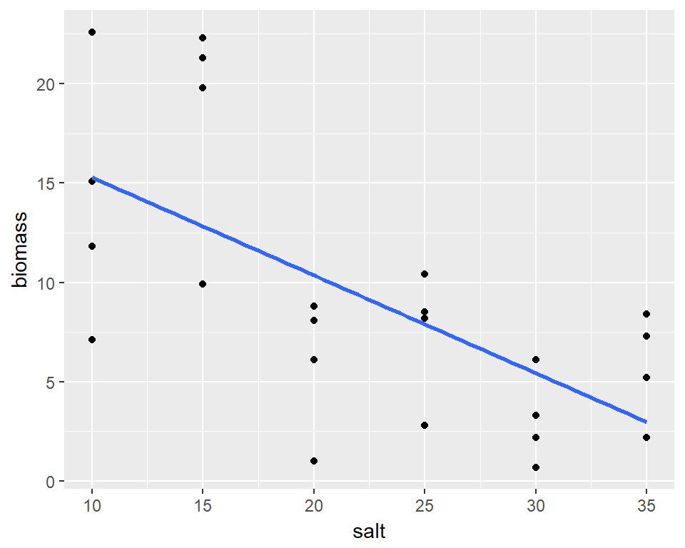

```r
p <- qplot(salt, biomass, data = saltmarsh)
p + stat_smooth(method="lm", se=FALSE) # no standard error
```

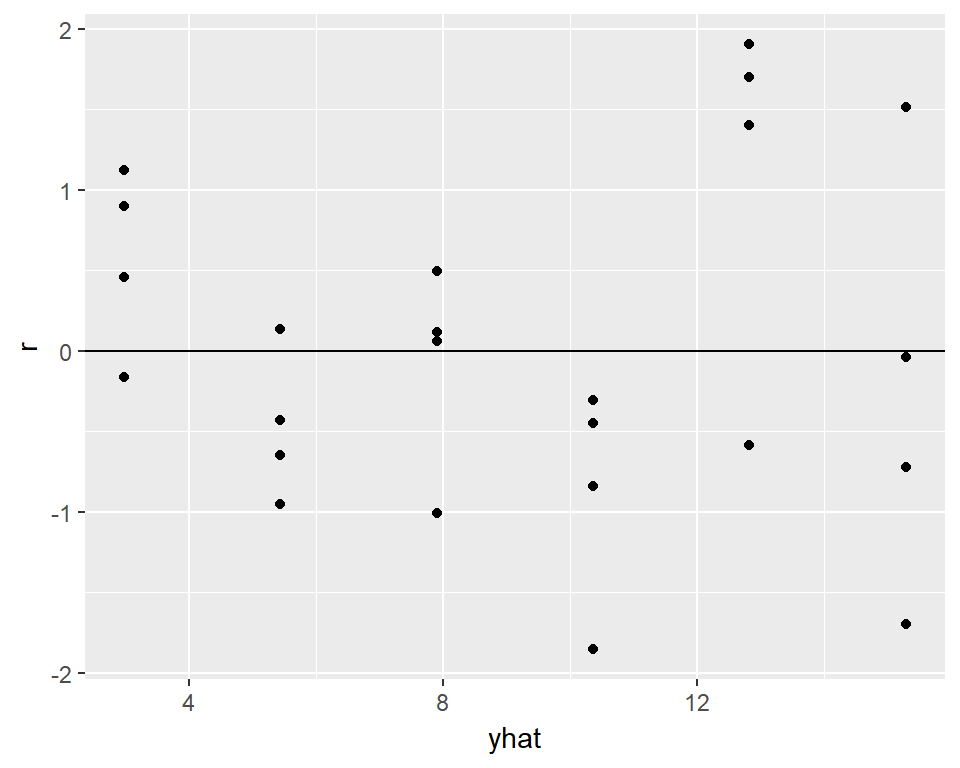

```r
R <- with(saltmarsh,
     cor(salt, biomass))
saltReg <- lm(biomass~salt, data = saltmarsh)
###############
r <- rstandard(saltReg)
yhat <- fitted(saltReg)
(linearity <- qplot(yhat, r) + geom_hline(aes(yintercept = 0)))
```

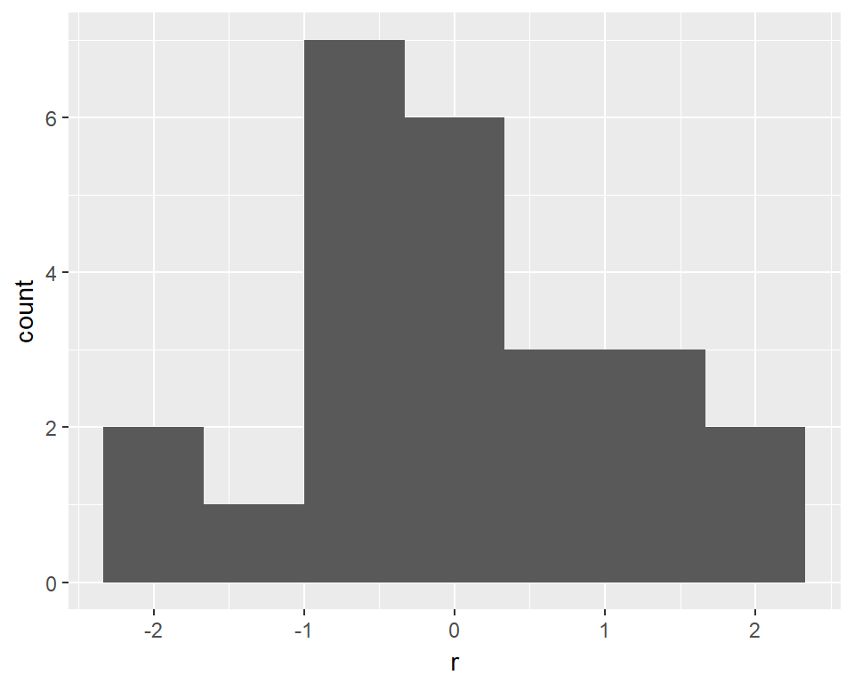

```r
(normality <- qplot(r, geom="histogram", binwidth=2/3))
```

```r
summary(saltReg)
```

```
##
## Call:
## lm(formula = biomass ~ salt, data = saltmarsh)
##
## Residuals:
##     Min      1Q  Median      3Q     Max
## -9.3640 -3.3026 -0.4833  2.9531  9.4745
##
## Coefficients:
##             Estimate Std. Error t value Pr(>|t|)
## (Intercept)  20.2098     2.9772   6.788 8.05e-07 ***
## salt         -0.4923     0.1237  -3.979 0.000634 ***
## ---
## Signif. codes:  0 '***' 0.001 '**' 0.01 '*' 0.05 '.' 0.1 ' ' 1
##
## Residual standard error: 5.175 on 22 degrees of freedom
## Multiple R-squared:  0.4185, Adjusted R-squared:  0.3921
## F-statistic: 15.83 on 1 and 22 DF,  p-value: 0.0006344
```

```r
confint(saltReg)
```

```
##                  2.5 %     97.5 %
## (Intercept) 14.0353484 26.3841754
## salt        -0.7488487 -0.2357228
```

4. We have four assumptions to check: linearity, independent observations, constant variability, and normality. The data isn’t strongly linear and the assumption isn’t well met. The data having independent observations is an assumption on my part by the data being provided for me is assumed to be random enough. Most of the data points have a decent constant variability, though a few of the points seem to be outliers. The normality of the graph is also similar to the constant variability. Most of the data points seem to be evenly distanced away from the regression line, giving a fairly consistent average residual, though there is a cluster of four data points that skew the average residual.
5. While salt is at 0, the expected value of biomass is approximately 20.21. For every increment of salt, 5, our expected biomass decreases by 1/2 of 5, thus 2.5.
6. My adjusted R-squared is .3921. Therefore, 39.21% of the variation in biomass is explained by the least squares line on salt.
7. H0: B = 0; H1: B != 0 alpha = 0.02

```r
confint(saltReg, level = 0.98)
```

```
##                    1 %       99 %
## (Intercept) 12.7418829 27.6776409
## salt        -0.8025955 -0.1819759
```

8. We are 98% confident when salt is 0, the amount of biomass is between 12.7 and 27.7 grams. We can reject the null hypothesis because our salt interval does not contain the null hypothesis. When there is no salt in the puddles, the expected amount of biomass is between 12.7 and 27.7 grams. Adding any amount of salt does not cause biomass to stay the same.